# Statistical Learning - Task 2

Online Shoppers Purchasing Intention

Sofía Gianelli

March, 2024

The aim of this project is to identify those individuals who will purchased some specific product by online. In order to simplify the work, we will assume that we are a company that sells books. We want to investigate if is possible to have an eCommerce, so we will proceed to analyze some variables related to the behavior of the individuals in a website. The variables to be taken into account are:

**Target**

- **Revenue**: Indicates whether the visit resulted in revenue generation. When the variable is “FALSE” means that the individual didn’t purchased at least one product, and when is equal to “TRUE” the individual did purchased.

**Categorical variables**

- **Month**: Represents the month of the visit.
- **Operating Systems**: Represents the visitor’s operating system.
- **Browser**: Represents the visitor’s browser.
- **Region**: Represents the visitor’s geographical region.
- **Traffic Type**: Represents the source of traffic to the website.
- **Visitor Type**: Represents whether the visitor is a returning or new visitor.
- **Weekend**: Indicates whether the visit occurred on a weekend.

**Numeric variables**

- **Administrative**: Represents the number of administrative pages visited by the visitor in a session.
- **Administrative Duration**: Represents the total time spent by the visitor on administrative pages.
- **Informational**: Represents the number of informational pages visited by the visitor in a session.
- **Informational Duration**: Represents the total time spent by the visitor on informational pages.
- **Product Related**: Represents the number of product-related pages visited by the visitor in a session.
- **Product Related Duration**: Represents the total time spent by the visitor on product-related pages.
- **Bounce Rates**: Represents the percentage of visits in which the visitor left the site from the landing page.
- **Exit Rates**: Represents the percentage of exits from the website.
- **Page Values**: Represents the average value for a web page that a user visited before completing an e-commerce transaction.
- **Special Day**: Indicates the closeness of the site visiting time to a specific special day, such as Valentine’s Day or Mother’s Day.

# 1 Pre-processing

## 1.1 Libraries and loading the dataset

```r
library(readxl)
library(ggplot2)
library(caret)
library(VIM)
library(knitr)
library(reshape2)
library(corrplot)
library(gridExtra)
library(pROC)
library(MASS)
library(tidyr)
library(class)
library(e1071)
library(rpart)
library(rpart.plot)
library(randomForest)
library(gbm)
set.seed(1999)
```

```r
dataset <- read.csv("online_shoppers_intention.csv", sep = ",")
```

```r
summary(dataset)
```

```
##  Administrative   Administrative_Duration Informational
##  Min.   : 0.000   Min.   :   0.00         Min.   : 0.0000
##  1st Qu.: 0.000   1st Qu.:   0.00         1st Qu.: 0.0000
##  Median : 1.000   Median :   7.50         Median : 0.0000
##  Mean   : 2.315   Mean   :  80.82         Mean   : 0.5036
##  3rd Qu.: 4.000   3rd Qu.:  93.26         3rd Qu.: 0.0000
##  Max.   :27.000   Max.   :3398.75         Max.   :24.0000
##  Informational_Duration ProductRelated   ProductRelated_Duration
##  Min.   :   0.00        Min.   :  0.00   Min.   :    0.0
##  1st Qu.:   0.00        1st Qu.:  7.00   1st Qu.:  184.1
##  Median :   0.00        Median : 18.00   Median :  598.9
##  Mean   :  34.47        Mean   : 31.73   Mean   : 1194.8
##  3rd Qu.:   0.00        3rd Qu.: 38.00   3rd Qu.: 1464.2
##  Max.   :2549.38        Max.   :705.00   Max.   :63973.5
##   BounceRates         ExitRates         PageValues        SpecialDay
##  Min.   :0.000000   Min.   :0.00000   Min.   :  0.000   Min.   :0.00000
##  1st Qu.:0.000000   1st Qu.:0.01429   1st Qu.:  0.000   1st Qu.:0.00000
##  Median :0.003112   Median :0.02516   Median :  0.000   Median :0.00000
##  Mean   :0.022191   Mean   :0.04307   Mean   :  5.889   Mean   :0.06143
##  3rd Qu.:0.016813   3rd Qu.:0.05000   3rd Qu.:  0.000   3rd Qu.:0.00000
##  Max.   :0.200000   Max.   :0.20000   Max.   :361.764   Max.   :1.00000
##     Month           OperatingSystems    Browser           Region
##  Length:12330       Min.   :1.000    Min.   : 1.000   Min.   :1.000
##  Class :character   1st Qu.:2.000    1st Qu.: 2.000   1st Qu.:1.000
##  Mode  :character   Median :2.000    Median : 2.000   Median :3.000
##                     Mean   :2.124    Mean   : 2.357   Mean   :3.147
##                     3rd Qu.:3.000    3rd Qu.: 2.000   3rd Qu.:4.000
##                     Max.   :8.000    Max.   :13.000   Max.   :9.000
##   TrafficType    VisitorType         Weekend         Revenue
##  Min.   : 1.00   Length:12330       Mode :logical   Mode :logical
##  1st Qu.: 2.00   Class :character   FALSE:9462      FALSE:10422
##  Median : 2.00   Mode  :character   TRUE :2868      TRUE :1908
##  Mean   : 4.07
##  3rd Qu.: 4.00
##  Max.   :20.00
```

In this case, we observed some basic statistics about the variables. We have 8 categorical variables and 10 numeric. In general, the variables don’t have so much variablity in their distributions.

## 1.2 Duplicates and Colnames

The next step was to check if there exist duplicated rows.

```r
# Checking for duplicated rows
print(paste("Duplicate rows:", sum(duplicated(dataset))))
```

```
## [1] "Duplicate rows: 125"
```

As we can observe the dataset contains duplicate rows, so we will proceed to remove it.

[output not shown]

Now, we have 0 duplicate rows.

## 1.3 Categorical variables into factor

Before spliting the dataset into train and test, we wanted to maintain the order into the subsets so we ordered the variables like: first the categorical variables and then the numeric ones.

```r
# Categorical first, then numeric
dataset <- dataset[,c(18,11,12,13,14,15,16,17,1,2,3,4,5,6,7,8,9,10)]
```

Before proceed to make some data visualization we had to change the string of the categorical variables into factor form in the dataset.

```r
dataset$Revenue <- ifelse(dataset$Revenue == "TRUE", "TRUE", "FALSE")
# Categorical as factor
dataset[, 1:8] <- lapply(dataset[, 1:8], factor)
```

## 1.4 Split train and test

After cleaning the dataset, we split it into training and testing subsets to facilitate model development and evaluation. We divided into 80% train and 20% test. As we want to do it well, we ensure that the proportion of each class is preserved across both sets, leading to more representative model evaluation.

```r
table(dataset$Revenue)/length(dataset$Revenue)
```

```
##
##     FALSE      TRUE
## 0.8436706 0.1563294
```

We have a 84,37% of the individuals that didn’t purchased the product, but the rest of the 15,63% purchased it.

```r
in_train <- createDataPartition(dataset$Revenue, p = 0.8, list = FALSE)  # 80% for training
train <- dataset[ in_train,]
test <- dataset[-in_train,]
table(train$Revenue)/length(train$Revenue)
```

```
##
##     FALSE      TRUE
## 0.8436252 0.1563748
```

After splitting the dataset using the function **createDataPartition**, we ensured that the proportion remains exactly as before.

## 1.5 Treating the NA’s values

One common step of the pre-processing is to check and correct the missing values (NA’s), so the first thing that we made is corroborate if the train and test subset had missing values.

```r
sum(is.na(train))
```

```
## [1] 0
```

```r
sum(is.na(test))
```

```
## [1] 0
```

# 2 Exploratory Data Analysis

**Target**

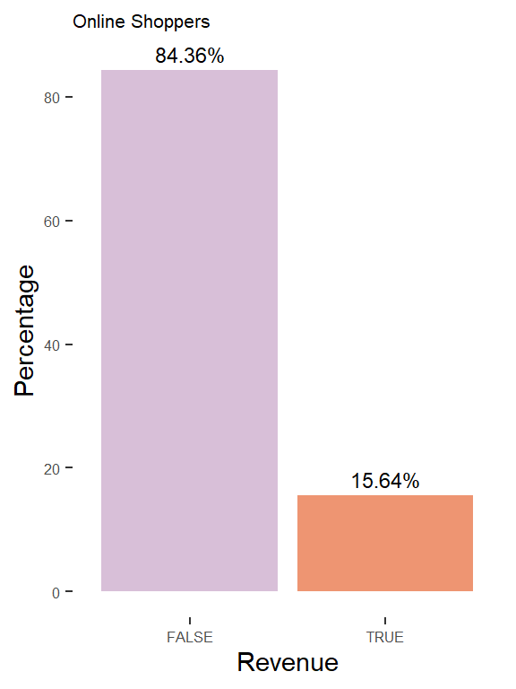

As we observed before, the are much more people who didn’t purchased a product even though they surfed in the website.

**Categorical Variables**

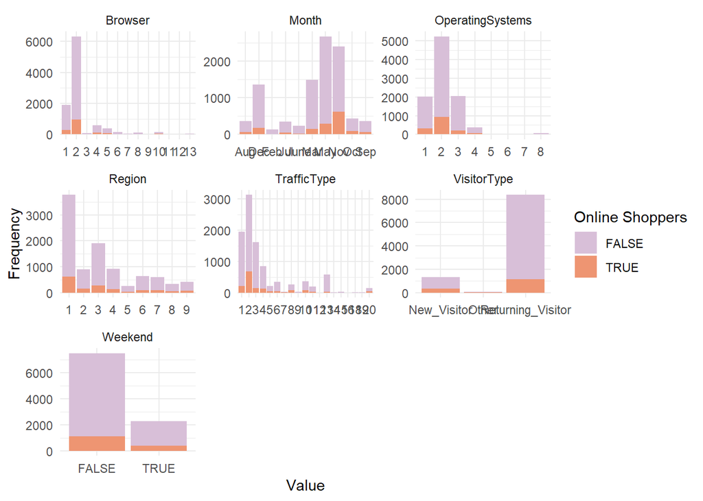

If we observe the above graphs, we could deduce that the most used browser is the type 2, that this could be the Google Chrome browser. The months with more views in the website are May, November and March. However, even though the month that more people visit the website is not the month that more people purchased the product, this month is November. The operating system most used is the type 2 one, we will assume that is Windows. Returning visitors are the people that visit and purchased the most. Finally, we can observe that on weekends, the individuals surf into the website and purchased less than in the in the week.

In addition, we observed that the variables TraffiyType and Browser have 1 or 0 observations in one of the levels, and this can cause some problems training the models, so we decided to remove them.

```r
# For TrafficType variable
train <- train[!(train$TrafficType %in% c("17", "12")), ]
train$TrafficType <- droplevels(train$TrafficType)
test <- test[!(test$TrafficType %in% c("17", "12")), ]
test$TrafficType <- droplevels(test$TrafficType)

# For Browser variable
train <- train[train$Browser != "9", ]
train$Browser <- droplevels(train$Browser)
test <- test[test$Browser != "9", ]
test$Browser <- droplevels(test$Browser)
```

**Numerical variables**

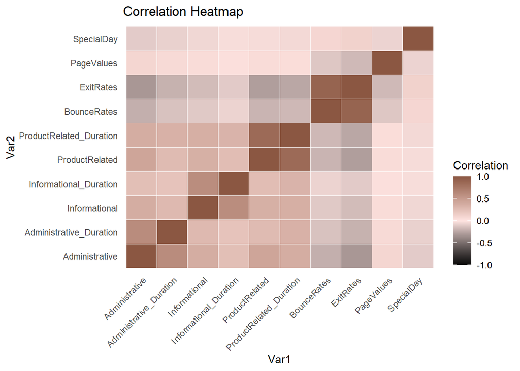

The previous heatmap is a correlation matrix of the numeric variables. The variable “administrative” is correlated with almost every variable except for “pagevalues”. In addition, we can see that the variables that have the number of visit and number of time spent in this type of page are highly correlated between them. Finally, “exitpages” is negative correlated with almost every variable, which makes sense.

The next step of this proyect is to discern the distribution of the numeric variables to check if we have to make some transformation to avoid problems in the future models.

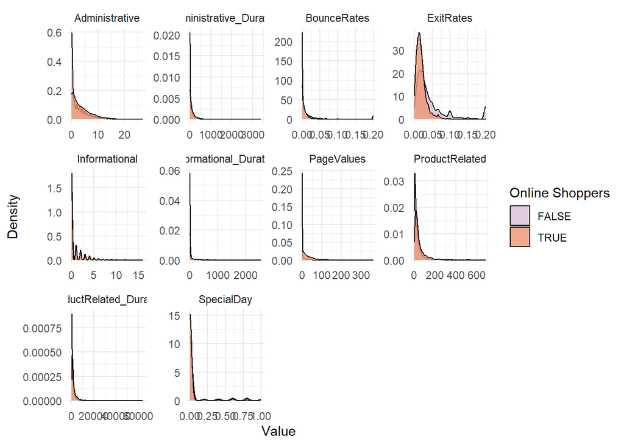

As we can observe, the distributions are concentrated in the left, with a huge concentration in zero. In order to continue evaluating which transformations make we will calculate the skewness and kurtosis of each variable. Skewness and kurtosis are statistical measures used to describe the shape of a distribution. Skewness measures the asymmetry of the distribution. It tells us whether the data is skewed to the left or right or whether it is symmetric. Kurtosis tells us whether the data is heavy-tailed or light-tailed compared to a normal distribution.

**Skewness and Kurtosis**

```r
# Calculate skewness and kurtosis for each variable individually
skewness_values <- numeric(length = ncol(train[, 9:18]))
kurtosis_values <- numeric(length = ncol(train[, 9:18]))

for (i in seq_along(skewness_values)) {
  skewness_values[i] <- skewness(train[, 9:18][[i]])
  kurtosis_values[i] <- kurtosis(train[, 9:18][[i]])
}

# Create a data frame for the skewness and kurtosis values
stats_df <- data.frame(
  Variable = colnames(train[, 9:18]),
  Skewness = round(skewness_values, 2),
  Kurtosis = round(kurtosis_values, 2),
  stringsAsFactors = FALSE
)

# Print the skewness table
kable(stats_df, caption = "Skewness and Kurtosis of Numeric Variables")
```

Skewness and Kurtosis of Numeric Variables

| Variable | Skewness | Kurtosis |
| --- | --- | --- |
| Administrative | 1.97 | 4.85 |
| Administrative_Duration | 5.46 | 48.75 |
| Informational | 3.70 | 18.91 |
| Informational_Duration | 7.44 | 73.24 |
| ProductRelated | 4.27 | 29.58 |
| ProductRelated_Duration | 7.26 | 144.62 |
| BounceRates | 3.16 | 9.36 |
| ExitRates | 2.24 | 4.67 |
| PageValues | 6.57 | 70.05 |
| SpecialDay | 3.29 | 9.81 |

The skewness and kurtosis are both positive, and some variables with high values, so we can deduce that the distributions is on the right side with heavy tails compared to a normal distribution. After analyse the graphs and the statistical measures we decide to transform every numeric variable applying the logarithm + 10 to make the distribution more symetric.

## 2.1 Transformations

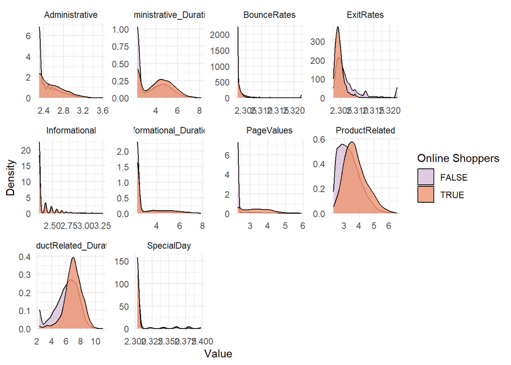

```r
# logarithmic transformations
train[,9:18] <- log(train[,9:18]+10)
```

Some variables didn’t change much after applying the transformation but some of them like ProductRelated and ProductRelated_Duration are much better, so will continue the analysis with the variables transformed.

## 2.2 Outliers

The models that we are going to perform in the following stage can be sensitive to outliers so we tried to identify and remove them before performing the models. To check if the variables have outliers so we made boxplot graph to identify them.

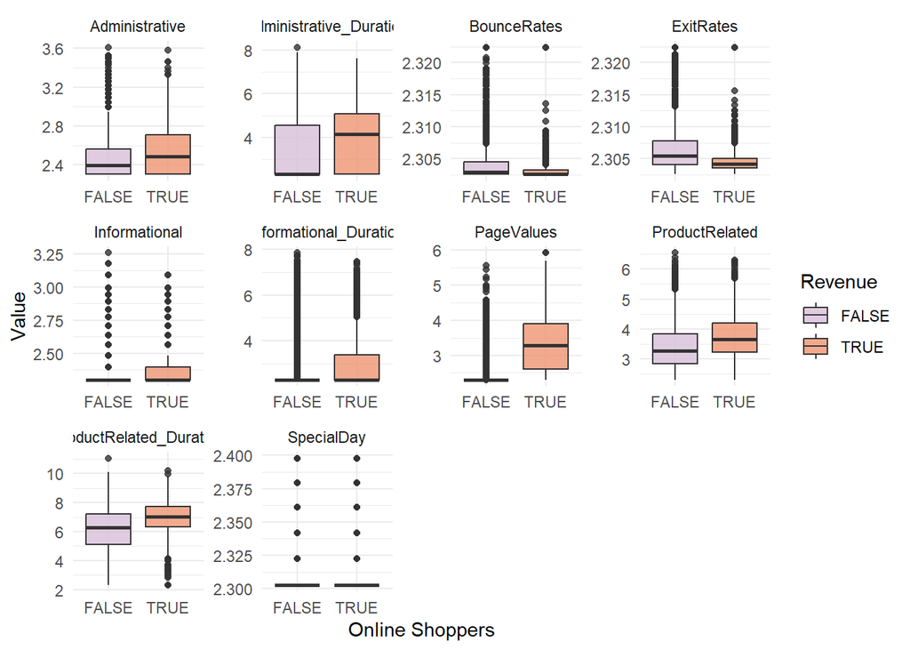

As we can observe, there is some outliers, so we will use a function to remove it.

```r
outlier_detection <- function(df, n, columns) {
  rows <- c()
  will_drop_train <- c()
  for (col in columns) {
    Q1 <- quantile(df[[col]], 0.25, na.rm = TRUE)
    Q3 <- quantile(df[[col]], 0.75, na.rm = TRUE)
    IQR <- Q3 - Q1
    outlier_point <- 1.5 * IQR
    rows <- c(rows, which(df[[col]] < Q1 - outlier_point | df[[col]] > Q3 + outlier_point))
  }
  row_counts <- table(rows)
  for (r in names(row_counts)) {
    if (row_counts[r] >= n) {
      will_drop_train <- c(will_drop_train, as.integer(r))
    }
  }
  return(will_drop_train)
}
```

```r
will_drop_train <- outlier_detection(train, 5, names(train)[sapply(train, is.numeric)])
head(will_drop_train, 5)
```

```
## [1]  400 1755 1851 1900 2474
```

```r
train <- train[-will_drop_train, ]
```

```r
will_drop_test <- outlier_detection(test, 5, names(test)[sapply(test, is.numeric)])
head(will_drop_test, 5)
```

```
## [1]  63  88 103 122 167
```

```r
test <- test[-will_drop_test, ]
```

We detected outliers from test and train dataset and we removed it. The output give us the index of the outliers removed.

## 2.3 Scalling

The last step before perform the model was to scale the numeric variables, because the variables weren’t in the same scale and this might be detrimental for the performance.

```r
train[,9:18] <- scale(train[,9:18])
test[,9:18] <- scale(test[,9:18])
```

# 3 Modelling

## 3.1 K-Nearest Neighbors

The k-Nearest Neighbors (k-NN) classifier is an algorithm that stores the entire training dataset in memory. Then, when making predictions, it identifies the k-nearest neighbors (data points) to the new instance based on distance metrics, normally it use the Euclidean distance. The majority class label among these neighbors is then assigned as the predicted label for the new instance.

### 3.1.1 Training

```r
ctrl <- trainControl(method = "cv",
                     number = 5,
                     classProbs = F,
                     verboseIter=F)
```

```r
knnFit <- train(Revenue ~ .,
                method = "knn",
                data = train,
                preProcess = c("center", "scale"),
                tuneLength = 10,
                trControl = ctrl)
```

### 3.1.2 Predictions

```r
knnPred <- predict(knnFit, test)
knn_cm <- confusionMatrix(knnPred,test$Revenue)
knn_cm
```

```
## Confusion Matrix and Statistics
##
##           Reference
## Prediction FALSE TRUE
##      FALSE  1971  275
##      TRUE     26   72
##
##                Accuracy : 0.8716
##                  95% CI : (0.8574, 0.8849)
##     No Information Rate : 0.852
##     P-Value [Acc > NIR] : 0.003572
##
##                   Kappa : 0.2764
##
##  Mcnemar's Test P-Value : < 2.2e-16
##
##             Sensitivity : 0.9870
##             Specificity : 0.2075
##          Pos Pred Value : 0.8776
##          Neg Pred Value : 0.7347
##              Prevalence : 0.8520
##          Detection Rate : 0.8409
##    Detection Prevalence : 0.9582
##       Balanced Accuracy : 0.5972
##
##        'Positive' Class : FALSE
##
```

The accuracy is 87% which is good but the number of false negative is higher that we desire for this project.

## 3.2 Neural Networks

Neural Networks is a class of machine learning models inspired by the structure and function of the human brain. They consist of interconnected layers of artificial neurons that process and transform input data to produce output predictions. They’re made up of layers of “neurons” that process information, which receive input signals, apply a mathematical transformation, and pass the result to the next layer. These layers are typically organized into an input layer, one or more hidden layers, and an output layer. Then the network finally makes a prediction.

### 3.2.1 Training

```r
# NN with 1 hidden layer
nnFit <- train(Revenue ~.,
                  method = "nnet",
                  data = train,
                  preProcess = c("center", "scale"),
                  MaxNWts = 1000,
                  maxit = 100,
                  tuneGrid = expand.grid(size=c(2,4,6), decay=c(0.01,0.001)),
                  maximize = F,
                  trControl = ctrl)
```

### 3.2.2 Predictions

```r
nnPred <- predict(nnFit, newdata=test)
nn_cm <- confusionMatrix(nnPred, test$Revenue)
nn_cm
```

```
## Confusion Matrix and Statistics
##
##           Reference
## Prediction FALSE TRUE
##      FALSE  1879  181
##      TRUE    118  166
##
##                Accuracy : 0.8724
##                  95% CI : (0.8583, 0.8857)
##     No Information Rate : 0.852
##     P-Value [Acc > NIR] : 0.0024688
##
##                   Kappa : 0.4533
##
##  Mcnemar's Test P-Value : 0.0003364
##
##             Sensitivity : 0.9409
##             Specificity : 0.4784
##          Pos Pred Value : 0.9121
##          Neg Pred Value : 0.5845
##              Prevalence : 0.8520
##          Detection Rate : 0.8016
##    Detection Prevalence : 0.8788
##       Balanced Accuracy : 0.7096
##
##        'Positive' Class : FALSE
##
```

The Network Neural obtained an accuracy of 87%.

## 3.3 SVMs

Support Vector Machines (SVMs) are supervised learning models used, in this case, for classification. During training, SVMs draw a line (or plane) that separates different groups of data points. This line is chosen so that it maximizes the space between the points of different categories.

### 3.3.1 Training

```r
svmFit <- train(Revenue ~., method = "svmRadial",
                data = train,
                preProcess = c("center", "scale"),
                tuneGrid = expand.grid(C = c(.25, .5, 1),
                                      sigma = c(0.01,.05)),
                trControl = ctrl)
```

### 3.3.2 Predictions

```r
svm_Pred <- predict(svmFit, newdata=test)
svm_cm <- confusionMatrix(svm_Pred, test$Revenue)
svm_cm
```

```
## Confusion Matrix and Statistics
##
##           Reference
## Prediction FALSE TRUE
##      FALSE  1963  215
##      TRUE     34  132
##
##                Accuracy : 0.8938
##                  95% CI : (0.8806, 0.906)
##     No Information Rate : 0.852
##     P-Value [Acc > NIR] : 1.653e-09
##
##                   Kappa : 0.4632
##
##  Mcnemar's Test P-Value : < 2.2e-16
##
##             Sensitivity : 0.9830
##             Specificity : 0.3804
##          Pos Pred Value : 0.9013
##          Neg Pred Value : 0.7952
##              Prevalence : 0.8520
##          Detection Rate : 0.8375
##    Detection Prevalence : 0.9292
##       Balanced Accuracy : 0.6817
##
##        'Positive' Class : FALSE
##
```

The SVM obtained an accuracy of 89%.

## 3.4 Decision trees

Decision Tree is a Supervised learning technique that can be used for solving Classification problems. It is a tree-structured classifier, where internal nodes represent the features of a dataset, branches represent the decision rules and each leaf node represents the outcome. In a Decision tree, there are two nodes, which are the Decision Node and Leaf Node. Decision nodes are used to make any decision and have multiple branches, whereas Leaf nodes are the output of those decisions and do not contain any further branches.

### 3.4.1 Training

```r
dt_grid <- expand.grid(.winnow = c(TRUE, FALSE),
                    .trials = c(1, 5, 7),
                    .model="tree" )

dtFit <- train(Revenue ~.,
                data=train,
                method="C5.0",
                tuneGrid = dt_grid,
                trControl = ctrl)
```

### 3.4.2 Predictions

```r
DT_pred <- predict(dtFit, test)
DT_cm <- confusionMatrix(DT_pred, test$Revenue)
DT_cm
```

```
## Confusion Matrix and Statistics
##
##           Reference
## Prediction FALSE TRUE
##      FALSE   776   71
##      TRUE   1221  276
##
##                Accuracy : 0.4488
##                  95% CI : (0.4285, 0.4692)
##     No Information Rate : 0.852
##     P-Value [Acc > NIR] : 1
##
##                   Kappa : 0.0777
##
##  Mcnemar's Test P-Value : <2e-16
##
##             Sensitivity : 0.3886
##             Specificity : 0.7954
##          Pos Pred Value : 0.9162
##          Neg Pred Value : 0.1844
##              Prevalence : 0.8520
##          Detection Rate : 0.3311
##    Detection Prevalence : 0.3613
##       Balanced Accuracy : 0.5920
##
##        'Positive' Class : FALSE
##
```

Even though the accuracy is 45% which is a much smaller than the other, but the error of false negative is smaller which is good.

## 3.5 Random Forests

Random Forest is a popular machine learning algorithm that belongs to the supervised learning technique. It is based on the concept of ensemble learning, which is a process of combining multiple classifiers to solve a complex problem and to improve the performance of the model. Instead of relying on one decision tree, the random forest takes the prediction from each tree and based on the majority votes of predictions, and it predicts the final output.

### 3.5.1 Training

```r
rfFit <- train(Revenue ~.,
                  method = "rf",
                  data = train,
                  preProcess = c("center", "scale"),
                  ntree = 200,
                  cutoff=c(0.7,0.3),
                  tuneGrid = expand.grid(mtry=c(6,8,10)),
                  maximize = F,
                  trControl = ctrl)
```

### 3.5.2 Predictions

```r
rf_pred <- predict(rfFit, newdata=test)
rf_cm <- confusionMatrix(rf_pred, test$Revenue)
rf_cm
```

```
## Confusion Matrix and Statistics
##
##           Reference
## Prediction FALSE TRUE
##      FALSE  1815   83
##      TRUE    182  264
##
##                Accuracy : 0.8869
##                  95% CI : (0.8734, 0.8995)
##     No Information Rate : 0.852
##     P-Value [Acc > NIR] : 4.677e-07
##
##                   Kappa : 0.5991
##
##  Mcnemar's Test P-Value : 1.743e-09
##
##             Sensitivity : 0.9089
##             Specificity : 0.7608
##          Pos Pred Value : 0.9563
##          Neg Pred Value : 0.5919
##              Prevalence : 0.8520
##          Detection Rate : 0.7743
##    Detection Prevalence : 0.8097
##       Balanced Accuracy : 0.8348
##
##        'Positive' Class : FALSE
##
```

Random Forest obtained an accuracy of 89% which is a great result so far, additionally, this model minimized the error of false negative.

## 3.6 Gradient boosting

Gradient Boosting is an ensemble learning technique used for classification. It constructs each new model to correct the errors of the ensemble so far. It focus on the residuals, or the differences between the actual and predicted values, of the previous models. This process is guided by gradient descent optimization, where each new model is trained to minimize a chosen loss function, such as mean squared error or cross-entropy loss.

### 3.6.1 Training

```r
GBMFit <- gbm(ifelse(train$Revenue=="FALSE",0,1) ~.,
              data=train,
              distribution= "bernoulli",
              n.trees=250,
              shrinkage = 0.01,
              interaction.depth=2,
              n.minobsinnode = 8)
```

### 3.6.2 Predictions

```r
threshold <- 0.5
gbm_prob <- predict(GBMFit, newdata=test, n.trees=250, type="response")
gbm_pred <- ifelse(gbm_prob > threshold, "TRUE", "FALSE")
gbm_cm <- confusionMatrix(as.factor(gbm_pred), test$Revenue)
gbm_cm
```

```
## Confusion Matrix and Statistics
##
##           Reference
## Prediction FALSE TRUE
##      FALSE  1955  187
##      TRUE     42  160
##
##                Accuracy : 0.9023
##                  95% CI : (0.8896, 0.914)
##     No Information Rate : 0.852
##     P-Value [Acc > NIR] : 2.9e-13
##
##                   Kappa : 0.5319
##
##  Mcnemar's Test P-Value : < 2e-16
##
##             Sensitivity : 0.9790
##             Specificity : 0.4611
##          Pos Pred Value : 0.9127
##          Neg Pred Value : 0.7921
##              Prevalence : 0.8520
##          Detection Rate : 0.8340
##    Detection Prevalence : 0.9138
##       Balanced Accuracy : 0.7200
##
##        'Positive' Class : FALSE
##
```

The accuracy of the Gradient boosting (90%) is the highest of the models trained in this project.

# 4 Comparative

In this part, we will compare each model performed before. We will use the accuracy, the kappa, the roc and the auc.

## 4.1 Accuracy

| Model | Kappa | Accuracy |
| --- | --- | --- |
| KNN | 27.64% | 87.16% |
| Neural Network | 45.33% | 87.24% |
| SVM | 46.32% | 89.38% |
| Decision Tree | 7.77% | 44.88% |
| Random Forest | 59.91% | 88.69% |
| Gradient Boosting | 53.19% | 90.23% |

Based on the provided Kappa and Accuracy values:

- Random Forest has the highest Kappa (60%) and a relatively high Accuracy (88%), making it a strong contender.
- Gradient Boosting also shows promising performance with a high Accuracy (90%) and a decent Kappa (53%).

## 4.2 ROC

Finally, once the models were implemented, we made the ROC curves. This is a graphical representation that illustrates the performance of a binary classification model across various threshold settings. It plots the true positive rate (sensitivity) against the false positive rate (specificity) for different threshold values. The area under the ROC curve (AUC) quantifies the model’s ability to distinguish between the two classes, with higher AUC values indicating better discrimination performance.

[figure not shown]

| Model | AUC |
| --- | --- |
| KNN | 0.60 |
| NN | 0.71 |
| SVM | 0.68 |
| DT | 0.59 |
| RF | 0.83 |
| GBM | 0.91 |

After analyzed the models accuracy, kappa and AUC. We will continue with Random Forest and Gradient Boosting incorporating an economic impact.

# 5 Economic impact

Remember that this project is to investigate the possibility of having an ecommerce, and find the individuals that will buy the product after surfed in the website. In order to achieve this goal, we need to plan a model focusing in reduce the false negative. Which means, reduce the predicted “FALSE” that are indeed “TRUE”, to capture the individuals with intentions to buy the products.

Lets refresh the confusion matrix of the two model selected before.

**Random Forest:**

```r
rf_cm$table
```

```
##           Reference
## Prediction FALSE TRUE
##      FALSE  1815   83
##      TRUE    182  264
```

**Gradient Boosting**

```r
gbm_cm$table
```

```
##           Reference
## Prediction FALSE TRUE
##      FALSE  1955  187
##      TRUE     42  160
```

To carry out this analysis, we need to assign costs or profits to different classification outcomes. Here’s a suggestion based on the provided information:

```r
cost.unit <- c(0, 100, 1000, 200)
```

```r
EconomicCost <- function(data, lev = NULL, model = NULL) {
  y.pred = data$pred
  y.true = data$obs
  CM = confusionMatrix(y.pred, y.true)$table
  out = sum(as.vector(CM) * cost.unit) / sum(CM)
  names(out) <- c("EconomicCost")
  out
}
```

```r
EconomicCost(data = data.frame(pred = rf_pred, obs = test$Revenue))
```

```
## EconomicCost
##     65.69966
```

```r
newctrl <- trainControl(method = "cv", number = 5,
                     classProbs = FALSE,
                     summaryFunction = EconomicCost,
                     verboseIter = FALSE)
```

**Random Forest**

```r
rf_train <- train(Revenue ~ .,
                  method = "rf",
                  data = train,
                  preProcess = c("center", "scale"),
                  ntree = 200,
                  cutoff = c(0.7, 0.3),
                  tuneGrid = expand.grid(mtry = c(6, 8, 10)),
                  metric = "EconomicCost",
                  maximize = FALSE,
                  trControl = newctrl)
```

```r
final_rf_pred <- predict(rf_train, newdata=test)
final_rf_cm <- confusionMatrix(final_rf_pred, test$Revenue)
final_rf_cm
```

```
## Confusion Matrix and Statistics
##
##           Reference
## Prediction FALSE TRUE
##      FALSE  1788   83
##      TRUE    209  264
##
##                Accuracy : 0.8754
##                  95% CI : (0.8614, 0.8885)
##     No Information Rate : 0.852
##     P-Value [Acc > NIR] : 0.0006051
##
##                   Kappa : 0.5706
##
##  Mcnemar's Test P-Value : 2.572e-13
##
##             Sensitivity : 0.8953
##             Specificity : 0.7608
##          Pos Pred Value : 0.9556
##          Neg Pred Value : 0.5581
##              Prevalence : 0.8520
##          Detection Rate : 0.7628
##    Detection Prevalence : 0.7982
##       Balanced Accuracy : 0.8281
##
##        'Positive' Class : FALSE
##
```

```r
threshold <- 0.2
final_rfProb <- predict(rf_train, newdata=test, type="prob")
final_rfPred = rep("FALSE", nrow(test))
final_rfPred[which(final_rfProb[,2] > threshold)] = "TRUE"
final_rfCM = confusionMatrix(factor(final_rfPred), test$Revenue)
final_rfCM
```

```
## Confusion Matrix and Statistics
##
##           Reference
## Prediction FALSE TRUE
##      FALSE  1455   42
##      TRUE    542  305
##
##                Accuracy : 0.7509
##                  95% CI : (0.7328, 0.7683)
##     No Information Rate : 0.852
##     P-Value [Acc > NIR] : 1
##
##                   Kappa : 0.3808
##
##  Mcnemar's Test P-Value : <2e-16
##
##             Sensitivity : 0.7286
##             Specificity : 0.8790
##          Pos Pred Value : 0.9719
##          Neg Pred Value : 0.3601
##              Prevalence : 0.8520
##          Detection Rate : 0.6207
##    Detection Prevalence : 0.6387
##       Balanced Accuracy : 0.8038
##
##        'Positive' Class : FALSE
##
```

Based on this result, we observe that although the cost per unit has increased, indicating a stricter penalty for misclassifications, the accuracy has decreased. However, this decrease in accuracy is accompanied by an increase in the number of individuals predicted to buy the product, which aligns with our primary goal.

**Gradient Boosting**

```r
final_GBMFit <- train(Revenue ~ .,
                        data=train,
                        trControl = newctrl,
                        metric="EconomicCost",
                        maximize = F,
                        tuneGrid = xgb_grid,
                        preProcess = c("center", "scale"),
                        method = "xgbTree"
)
```

[output not shown]

[output not shown]

[output cut: 65 more lines]

[output not shown]

```r
threshold <- 0.5
# Get the predicted probabilities
final_gbm_prob <- predict(final_GBMFit, newdata = test, n.trees = 250, type = "prob")

# Extract the class labels with the highest probability
final_gbm_pred <- ifelse(final_gbm_prob[, "TRUE"] > threshold, "TRUE", "FALSE")

# Convert predicted and actual classes to factors with the same levels
final_gbm_pred <- factor(final_gbm_pred, levels = c("FALSE","TRUE"))
test$Revenue <- factor(test$Revenue, levels = c("FALSE","TRUE"))

# Create confusion matrix
final_gbm_cm <- confusionMatrix(final_gbm_pred, test$Revenue)
final_gbm_cm
```

```
## Confusion Matrix and Statistics
##
##           Reference
## Prediction FALSE TRUE
##      FALSE  1859  135
##      TRUE    138  212
##
##                Accuracy : 0.8835
##                  95% CI : (0.8699, 0.8962)
##     No Information Rate : 0.852
##     P-Value [Acc > NIR] : 5.272e-06
##
##                   Kappa : 0.5399
##
##  Mcnemar's Test P-Value : 0.9037
##
##             Sensitivity : 0.9309
##             Specificity : 0.6110
##          Pos Pred Value : 0.9323
##          Neg Pred Value : 0.6057
##              Prevalence : 0.8520
##          Detection Rate : 0.7931
##    Detection Prevalence : 0.8507
##       Balanced Accuracy : 0.7709
##
##        'Positive' Class : FALSE
##
```

The accuracy decreased compare with the accuracy of the gradient boosting performed before, but the number of “TRUE” predicted well increased, which was our idea.

We will change the threshold and see if we can obtain a better confusion matrix.

```r
threshold <- 0.2
# Get the predicted probabilities
final_gbm_prob <- predict(final_GBMFit, newdata = test, n.trees = 250, type = "prob")

# Extract the class labels with the highest probability
final_gbm_pred <- ifelse(final_gbm_prob[, "TRUE"] > threshold, "TRUE", "FALSE")

# Convert predicted and actual classes to factors with the same levels
final_gbm_pred <- factor(final_gbm_pred, levels = c("FALSE","TRUE"))
test$Revenue <- factor(test$Revenue, levels = c("FALSE","TRUE"))

# Create confusion matrix
final_gbm_cm <- confusionMatrix(final_gbm_pred, test$Revenue)
final_gbm_cm
```

```
## Confusion Matrix and Statistics
##
##           Reference
## Prediction FALSE TRUE
##      FALSE   646   11
##      TRUE   1351  336
##
##                Accuracy : 0.4189
##                  95% CI : (0.3989, 0.4392)
##     No Information Rate : 0.852
##     P-Value [Acc > NIR] : 1
##
##                   Kappa : 0.1124
##
##  Mcnemar's Test P-Value : <2e-16
##
##             Sensitivity : 0.3235
##             Specificity : 0.9683
##          Pos Pred Value : 0.9833
##          Neg Pred Value : 0.1992
##              Prevalence : 0.8520
##          Detection Rate : 0.2756
##    Detection Prevalence : 0.2803
##       Balanced Accuracy : 0.6459
##
##        'Positive' Class : FALSE
##
```

The number of “TRUE” predicted well increased but the accuracy is much worst.

# 6 Conclusion